# Results from CIMLR

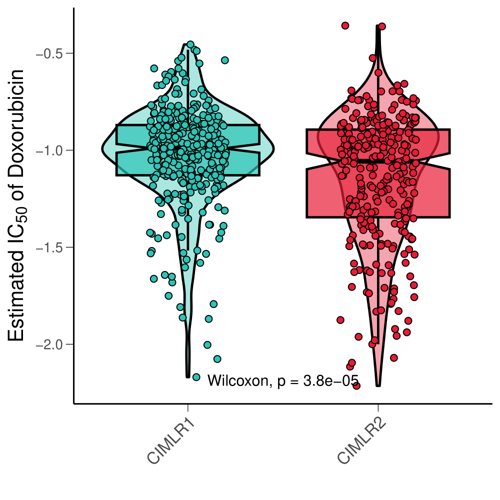

**Comparison with MOVICS consensus subtypes**:

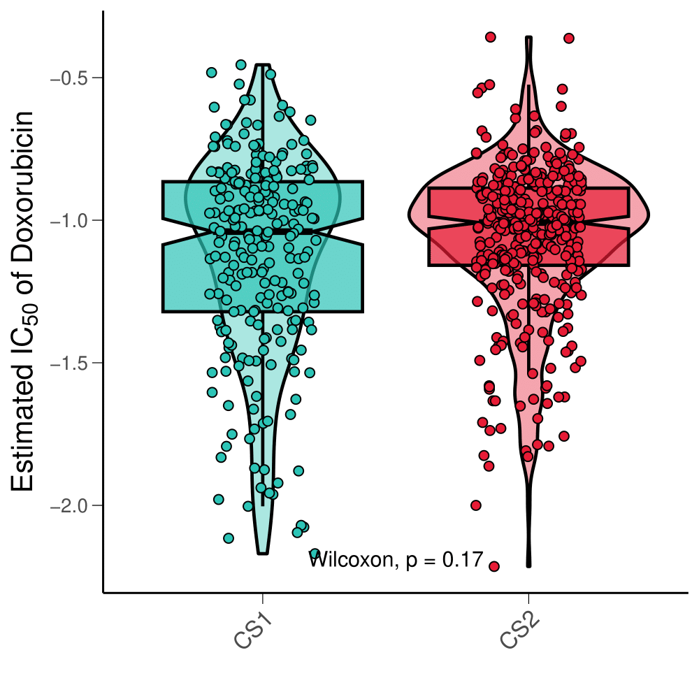

**Comparison with MOVICS CIMLR subtypes**:

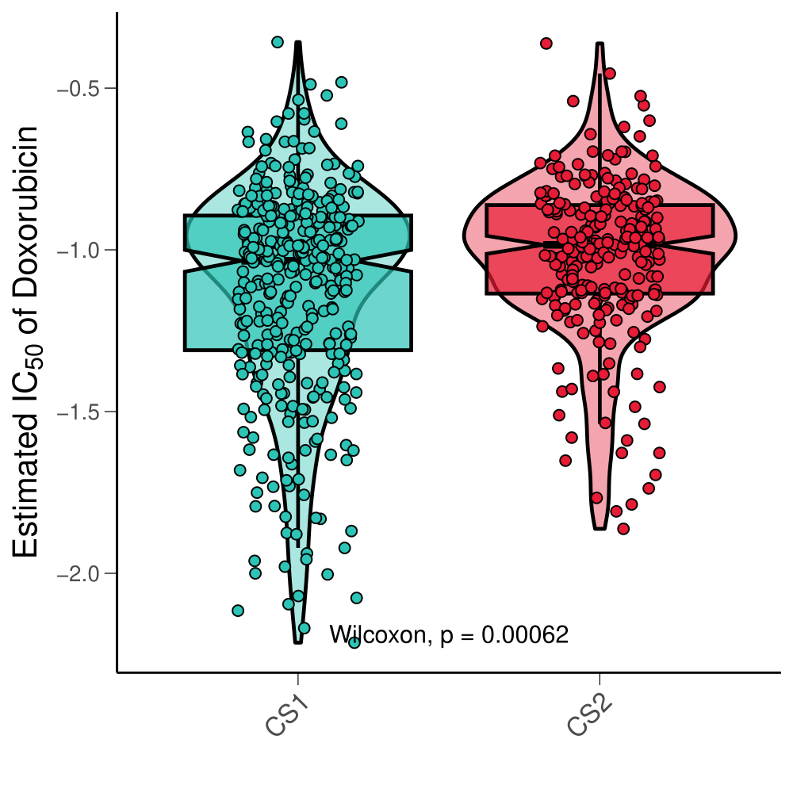

**Cisplatin**

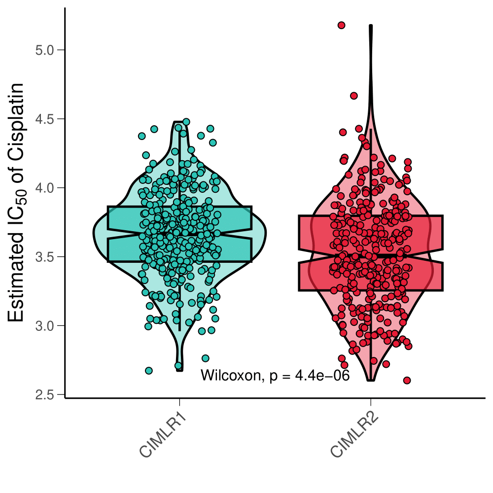

**Comparison with MOVICS consensus subtypes**:

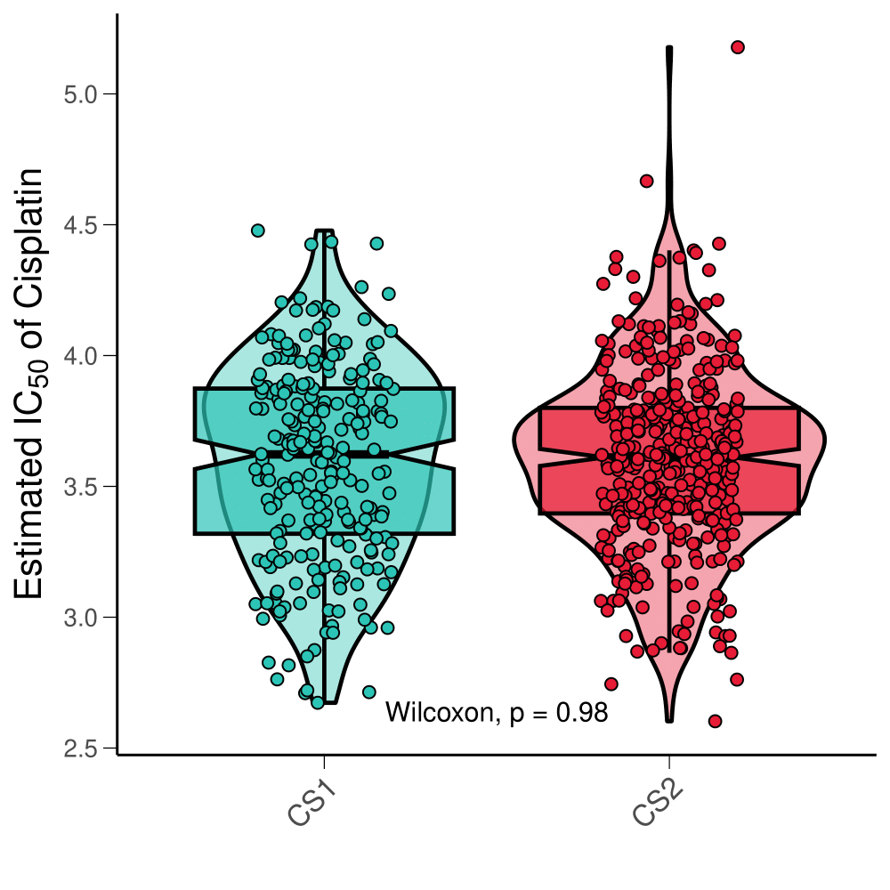

**Comparison with MOVICS CIMLR subtypes**:

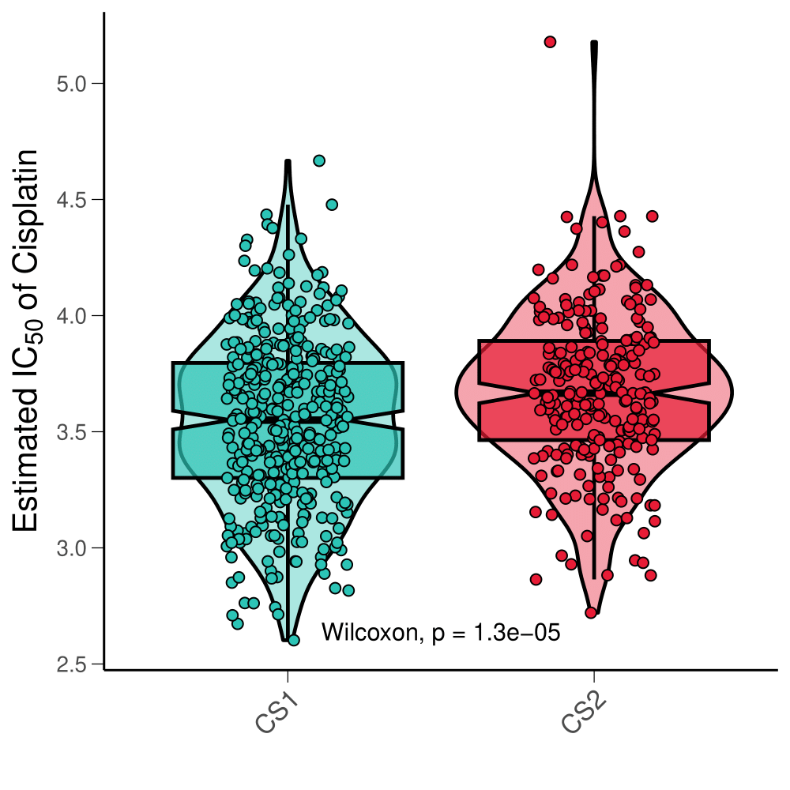

**5-Fluorouracil**

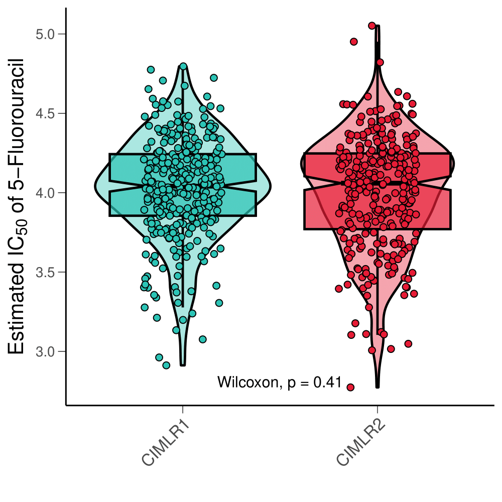

**Comparison with MOVICS consensus subtypes**:

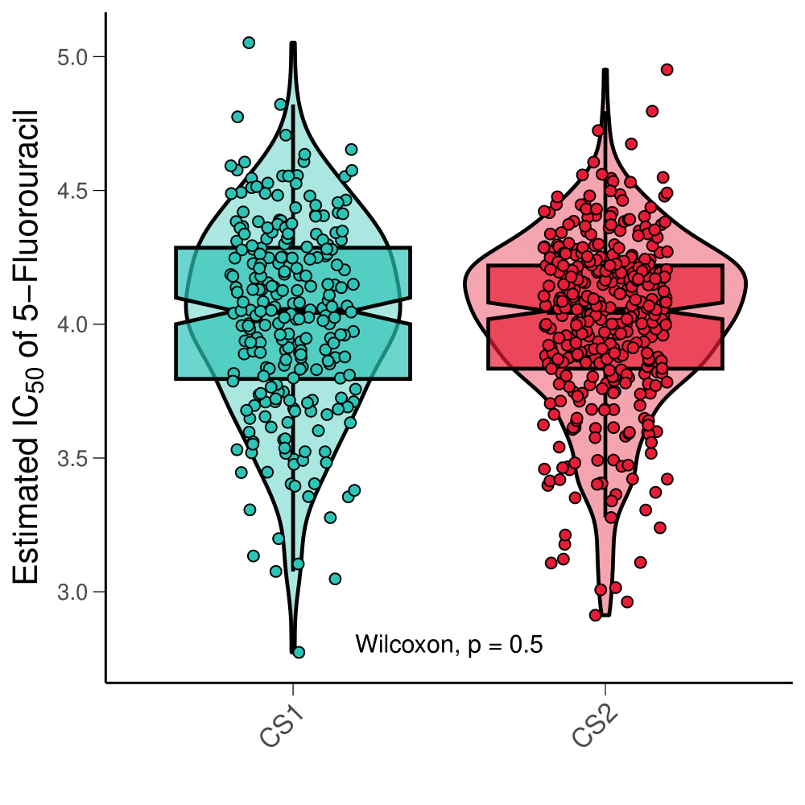

**Comparison with MOVICS CIMLR subtypes**:

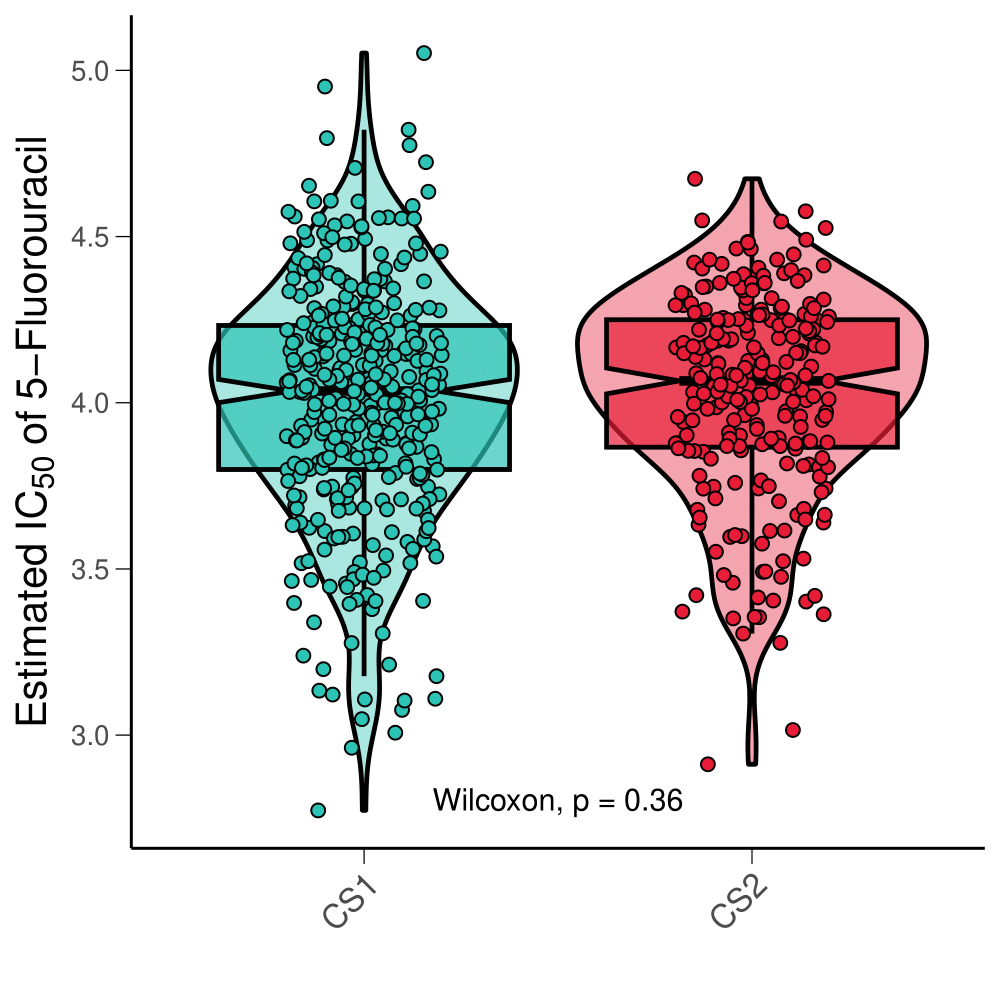

## Subtype agreement

Here we examine how similar the consensus multi-omic clustering labels are to other labels relative to breast cancer.

MOVICS provides function of `compAgree()` to calculate four statistics: Rand Index (RI), Adjusted Mutual Information (AMI), Jaccard Index (JI), and Fowlkes-Mallows (FM); all these measurements range from 0 to 1 and the larger the value is, the more similar the compared groups are.

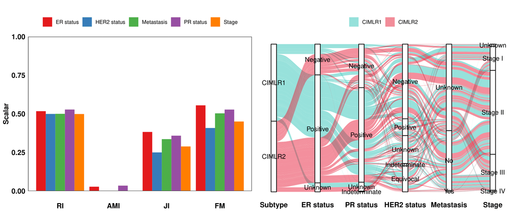

## Comparison to MOVICS CIMLR

In MOVICS, the CIMLR algorithm is run by default with $nn' = 10$ and using only Euclidean distances.

**ARI:** 0.0397416 **NMI:** 0.0355491

# Conclusions

1. The identified CIMLR subtypes are associated with **vital status, history of neoadjuvant treatment, PR status, ER status, HER2 status (not confirmed in bar charts), ER and PR cell level percentages, and histological type**.
2. The identified CIMLR subtypes are **NOT** similar to the MOVICS CIMLR subtypes (**ARI:** 0.0397416, **NMI:** 0.0355491).
3. Differential expression analysis of CIMLR clusters indicates that **the true number of clusters may be 3**; CIMLR1 may be split in two clusters, one of which is predominantly consisting of ER+ samples, and the other one has a noticeable proprotion of ER- samples.
4. CIMLR2 samples have (on average) up-regulated cell cycle pathways compared to CIMLR1.
5. CIMLR1 has a high proportion of *PIK3CA* **mutations** and CIMLR2 has a high proportion of *TP53* **mutations**. CIMLR1 has a relatively high ratio of *CDH1* mutations too.
6. In terms of **drug sensitivity**, CIMLR1 seems to be more sensitive to **sorafenib and lapatinib** compared to CIMLR2, and less sensitive to **doxorubicin and cisplatin**.
7. Predicted CIMLR subtypes on the transNEO cohort are associated with lymph node status at diagnosis, ER status, grade, **pCR** (see table below), PAM50, iC10, RCB score, STAT1.gsva score, GGI.gsva score, ESC.gsva score, TMB and HRD.sum.

Response rates across transNEO CIMLR subtypes

| Response | CIMLR1 | CIMLR2 |
| --- | --- | --- |
| pCR | 12 (14.0%) | 29 (43.3%) |
| Residual Disease | 74 (86.0%) | 38 (56.7%) |